# RNAseq 1

## 1-5. 重複遺伝子の除外

重複している遺伝子名を確認してみます。`duplicated`機能はベクトルの要素を順に確認していき、同じものが見つかった箇所にTRUEを入れて返します。(重複要素のうち1番最初に登場したものはFALSEです。)

```r
symbol <- symbol[,2]
table(duplicated(x = symbol))
```

```
##
## FALSE  TRUE
## 59429  1220
```

TRUE/FALSEの情報をindexに入れればTRUEの要素だけを確認できます。

```r
head(symbol[duplicated(symbol)], n = 50)
```

```
##  [1] "Metazoa_SRP" "Y_RNA"       "Y_RNA"       "Y_RNA"       "Y_RNA"
##  [6] "Y_RNA"       "Y_RNA"       "Y_RNA"       "Y_RNA"       "Y_RNA"
## [11] "Y_RNA"       "Y_RNA"       "Y_RNA"       "Y_RNA"       "Y_RNA"
## [16] "Y_RNA"       "Y_RNA"       "Y_RNA"       "Y_RNA"       "Y_RNA"
## [21] "Y_RNA"       "Y_RNA"       "Y_RNA"       "Y_RNA"       "Y_RNA"
## [26] "Y_RNA"       "Y_RNA"       "Y_RNA"       "Y_RNA"       "Y_RNA"
## [31] "Y_RNA"       "Y_RNA"       "Y_RNA"       "Y_RNA"       "Y_RNA"
## [36] "Y_RNA"       "Y_RNA"       "Y_RNA"       "Y_RNA"       "Y_RNA"
## [41] "Y_RNA"       "Y_RNA"       "Y_RNA"       "Y_RNA"       "Y_RNA"
## [46] "SNORA63"     "Y_RNA"       "Y_RNA"       "Y_RNA"       "Y_RNA"
```

```r
tail(symbol[duplicated(symbol)], n = 50)
```

```
##  [1] "5_8S_rRNA"      "U6"             "5_8S_rRNA"      "U6"
##  [5] "U6"             "U6"             "U6"             "U6"
##  [9] "Metazoa_SRP"    "U6"             "U6"             "U6"
## [13] "U6"             "Metazoa_SRP"    "U4"             "U6"
## [17] "U6"             "U6"             "U6"             "U2"
## [21] "U6"             "U6"             "U2"             "U6"
## [25] "5_8S_rRNA"      "U6"             "Y_RNA"          "Metazoa_SRP"
## [29] "U6"             "Y_RNA"          "BCRP3"          "MIR1539"
## [33] "MIR3179-1"      "PDE11A"         "CCDC39"         "LINC02203"
## [37] "TBCE"           "POLR2J3"        "LINC00941"      "OR7E11P"
## [41] "5S_rRNA"        "5S_rRNA"        "5S_rRNA"        "5S_rRNA"
## [45] "ANAPC1P2"       "5S_rRNA"        "SLFN12L"        "ARMCX5-GPRASP2"
## [49] "5S_rRNA"        "RNF216P1"
```

少し見てみるとわかるようにY染色体の遺伝子やリボソーム遺伝子などあまり重要そうではない遺伝子たちばかりです。

これらは解析対象から外しても問題無いと考えられます。  
実際のところ発現量は0のものばかりです。

```r
head(mat[duplicated(symbol), ], n = 10)
```

|  | sample1 | sample2 | sample3 |
| --- | --- | --- | --- |
| ENSG00000197334.2_Metazoa_SRP | 0 | 0 | 0 |
| ENSG00000199200.2_Y_RNA | 0 | 0 | 0 |
| ENSG00000199201.1_Y_RNA | 0 | 0 | 0 |
| ENSG00000199203.1_Y_RNA | 0 | 0 | 0 |
| ENSG00000199204.1_Y_RNA | 0 | 0 | 0 |
| ENSG00000199220.1_Y_RNA | 0 | 0 | 0 |
| ENSG00000199222.1_Y_RNA | 0 | 0 | 0 |
| ENSG00000199223.1_Y_RNA | 0 | 0 | 0 |
| ENSG00000199224.1_Y_RNA | 0 | 0 | 0 |
| ENSG00000199241.1_Y_RNA | 0 | 0 | 0 |

```r
tail(mat[duplicated(symbol), ], n = 10)
```

|  | sample1 | sample2 | sample3 |
| --- | --- | --- | --- |
| ENSG00000285609.1_5S_rRNA | 0.00 | 0.00 | 0.00 |
| ENSG00000285626.1_5S_rRNA | 0.00 | 0.00 | 0.00 |
| ENSG00000285674.1_5S_rRNA | 0.00 | 0.00 | 0.00 |
| ENSG00000285776.1_5S_rRNA | 0.00 | 0.00 | 0.00 |
| ENSG00000285793.1_ANAPC1P2 | 12.67 | 8.72 | 14.26 |
| ENSG00000285912.1_5S_rRNA | 0.00 | 0.00 | 0.00 |
| ENSG00000286065.2_SLFN12L | 0.00 | 0.00 | 0.00 |
| ENSG00000286237.1_ARMCX5-GPRASP2 | 0.72 | 0.79 | 0.66 |
| ENSG00000288601.1_5S_rRNA | 0.00 | 0.00 | 0.00 |
| ENSG00000288620.1_RNF216P1 | 0.00 | 0.00 | 0.01 |

そうは言っても発現値を持つものもあるので、重複遺伝子のうち最も発現が高いものを残して2番目以降は除くようにします。(重複遺伝子の発現値を合算するという方法でもよいです。)

`rowSums`機能で行の合計を集計します。(`rowMeans`や`colSums`, `colMeans`機能もあります。)

```r
head(rowSums(mat))
```

```
##   ENSG00000000003.15_TSPAN6      ENSG00000000005.6_TNMD
##                       59.69                       84.16
##     ENSG00000000419.14_DPM1    ENSG00000000457.14_SCYL3
##                      332.19                       20.68
## ENSG00000000460.17_C1orf112      ENSG00000000938.13_FGR
##                       67.63                        0.00
```

行の合計を降順に並び替えた遺伝子順を採用します。 orderで発現値を基に並び替えます。デフォルトでは昇順なので`decreasing = TRUE`にして降順に並び替えます。

```r
geneorder <- order(rowSums(mat), decreasing = TRUE)
mat <- mat[geneorder,]
head(mat)
```

|  | sample1 | sample2 | sample3 |
| --- | --- | --- | --- |
| ENSG00000228253.1_MT-ATP8 | 12853.31 | 6799.79 | 11234.63 |
| ENSG00000156508.19_EEF1A1 | 9681.80 | 11120.52 | 9603.46 |
| ENSG00000212907.2_MT-ND4L | 6892.81 | 5740.22 | 11435.48 |
| ENSG00000198840.2_MT-ND3 | 7125.35 | 5902.87 | 9275.51 |
| ENSG00000177954.14_RPS27 | 5109.38 | 5422.83 | 7485.42 |
| ENSG00000034510.6_TMSB10 | 4341.92 | 7645.50 | 5736.95 |

この並びの場合のduplicateを調べ直して、重複が無い箇所のみを取得します。

```r
symbol <- stringr::str_split(string = rownames(mat), pattern = "_", n = 2,simplify = TRUE)[,2]

# duplicateの出力を!で否定
symbol_unique <- !duplicated(symbol)

# TRUEの箇所のみ抽出
mat <- mat[symbol_unique,]
symbol <- symbol[symbol_unique]

rownames(mat) <- symbol

head(mat)
```

|  | sample1 | sample2 | sample3 |
| --- | --- | --- | --- |
| MT-ATP8 | 12853.31 | 6799.79 | 11234.63 |
| EEF1A1 | 9681.80 | 11120.52 | 9603.46 |
| MT-ND4L | 6892.81 | 5740.22 | 11435.48 |
| MT-ND3 | 7125.35 | 5902.87 | 9275.51 |
| RPS27 | 5109.38 | 5422.83 | 7485.42 |
| TMSB10 | 4341.92 | 7645.50 | 5736.95 |

```r
dim(mat)
```

```
## [1] 59429     3
```

やっと発現マトリクスが完成しました。

# 2. RNAseqデータのプロファイリング

発現マトリクスからサンプル間のプロファイルの違いを示すことができます。

サンプル数を増やしたデモデータを作成します。

```r
# ファイルパス一覧を取得
filepaths <- dir(path = "RNAseq_data/", pattern = "*results", full.names = T)

# ファイルの読み込みと処理の繰り返しを実行。出力はリスト
dat <- lapply(filepaths, function(x){
  x <- read.delim(file = x, header = T, sep = "\t")
  x <- x[,c("gene_id", "TPM")]
  rownames(x) <- x[,1]
  x[,1] <- NULL
  return(x)
})
# リストの要素をcbind
mat <- do.call(what = cbind, dat)
# 列名を付け直し
colnames(mat) <- paste0("sample", seq(6))

# 発現量で降順にソート
mat <- mat[order(rowSums(mat), decreasing = TRUE),]

symbol <- stringr::str_split(string = rownames(mat), pattern = "_", n = 2,simplify = TRUE)[,2]
# duplicateの出力を!で否定
symbol_unique <- !duplicated(symbol)

# TRUEの箇所のみ抽出
mat <- mat[symbol_unique,]
symbol <- symbol[symbol_unique]

# 行名に遺伝子名を入れる
rownames(mat) <- symbol
head(mat)
```

|  | sample1 | sample2 | sample3 | sample4 | sample5 | sample6 |
| --- | --- | --- | --- | --- | --- | --- |
| EEF1A1 | 9681.80 | 11120.52 | 9603.46 | 12109.72 | 11766.53 | 17771.28 |
| MT-ND4L | 6892.81 | 5740.22 | 11435.48 | 10347.64 | 13765.06 | 19637.28 |
| MT-ATP8 | 12853.31 | 6799.79 | 11234.63 | 10180.99 | 12764.41 | 11876.83 |
| MT-ND3 | 7125.35 | 5902.87 | 9275.51 | 8048.24 | 9736.77 | 12003.95 |
| MT-CO2 | 6347.25 | 4504.80 | 6743.09 | 11088.24 | 7743.59 | 14482.23 |
| RPS27 | 5109.38 | 5422.83 | 7485.42 | 6584.82 | 8056.69 | 10091.39 |

## 2-1. ヒートマップによる発現プロファイルの可視化

```r
library(pheatmap)
```

まずはpheatmapで簡単にデータを可視化してみます。

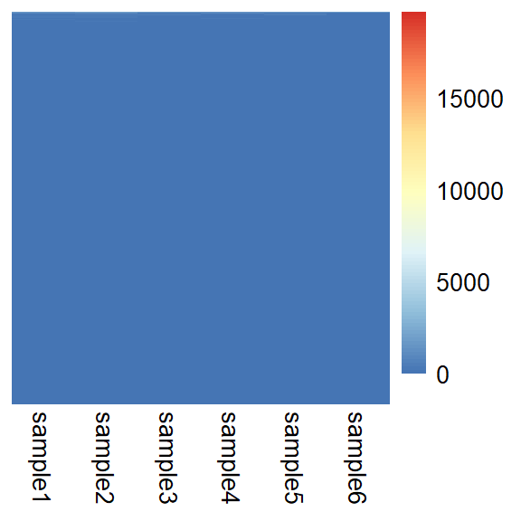

```r
pheatmap(mat = mat,
         cluster_rows = F,
         cluster_cols = F,
         show_rownames = F)
```

見ての通りデータが真っ青で、殆どの遺伝子が低発現に位置していることが分かります。

## 2-2. 低発現遺伝子のフィルタリング

分位数やヒストグラムで遺伝子発現量の分布を確認してみると、殆どの遺伝子が低発現な一方で、発現量が高い遺伝子は10000を超えた発現量を持っています。

```r
summary(rowMeans(mat))
```

```
##      Min.   1st Qu.    Median      Mean   3rd Qu.      Max.
##     0.000     0.000     0.000    16.825     0.857 12008.885
```

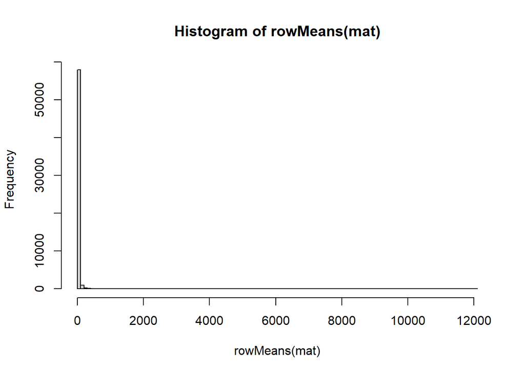

```r
hist(rowMeans(mat), breaks = 100)
```

発現量が全くない = 0のものを調べてみます。

```r
table(rowMeans(mat) == 0)
```

```
##
## FALSE  TRUE
## 24375 35054
```

半分以上の遺伝子は発現量が0であることがわかりました。

これらは意味を持ちませんので、解析から除きます。

```r
mat <- mat[rowMeans(mat) != 0, ]
dim(mat)
```

```
## [1] 24375     6
```

さらに発現のスケールを正規分布に近づけるために対数変換しておきます。値が0の箇所は対数変換できませんので、pseudocountとして一律に1を足しておきます。

```r
mat_log <- log2(mat + 1)
```

```r
summary(rowMeans(mat_log))
```

```
##      Min.   1st Qu.    Median      Mean   3rd Qu.      Max.
##  0.002393  0.232999  1.641814  2.505106  4.494453 13.519271
```

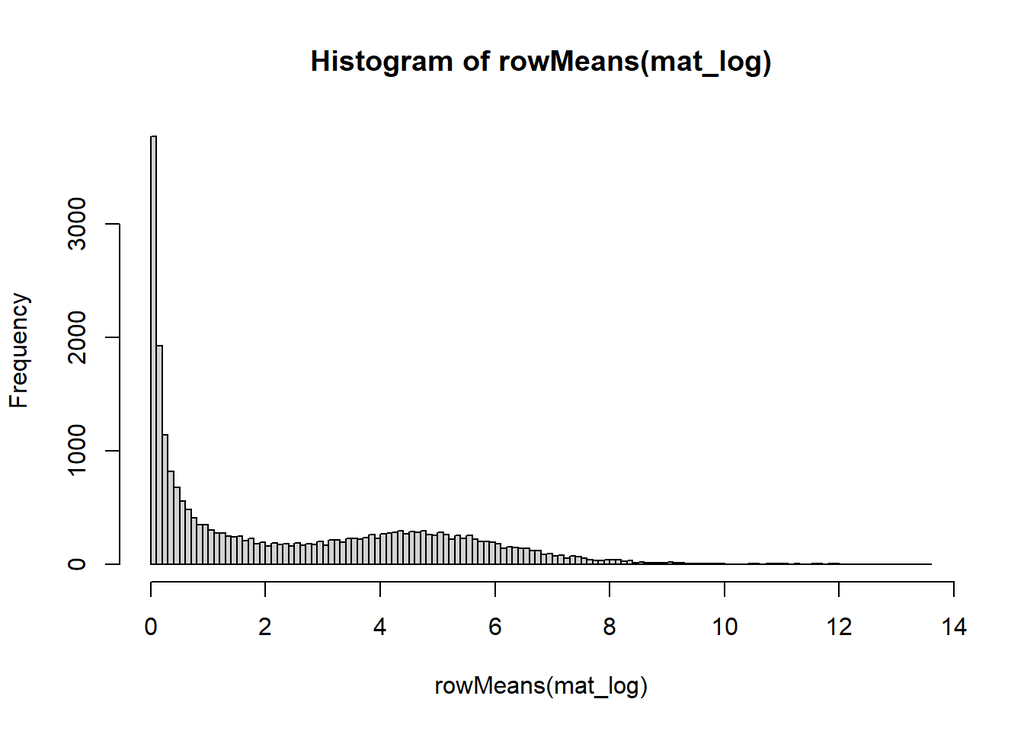

```r
hist(rowMeans(mat_log), breaks = 100)
```

発現分布の偏りが減少してきました。 しかし、まだまだ低発現遺伝子が最も多い状態には変わりません。

一般に、RNAseqではこれら低発現遺伝子もフィルタリングして解析に臨みます。もしかすると、低発現領域の遺伝子に大事な物があるのかもしれませんが、低発現遺伝子はphenotypeに影響は与えていないという想定の下で除くのは妥当な処理です。

カットオフ値は任意です。減らし過ぎず、残し過ぎない値を採用します。

```r
table(rowMeans(mat_log) > 1)
```

```
##
## FALSE  TRUE
## 10487 13888
```

```r
table(rowMeans(mat_log) > 2)
```

```
##
## FALSE  TRUE
## 12901 11474
```

```r
table(rowMeans(mat_log) > 5)
```

```
##
## FALSE  TRUE
## 19685  4690
```

ここではカットオフを1に設定してみます。

```r
mat_log <- mat_log[rowMeans(mat_log) > 1,]
dim(mat_log)
```

```
## [1] 13888     6
```

```r
summary(rowMeans(mat_log))
```

```
##    Min. 1st Qu.  Median    Mean 3rd Qu.    Max.
##   1.000   2.601   4.194   4.189   5.484  13.519
```

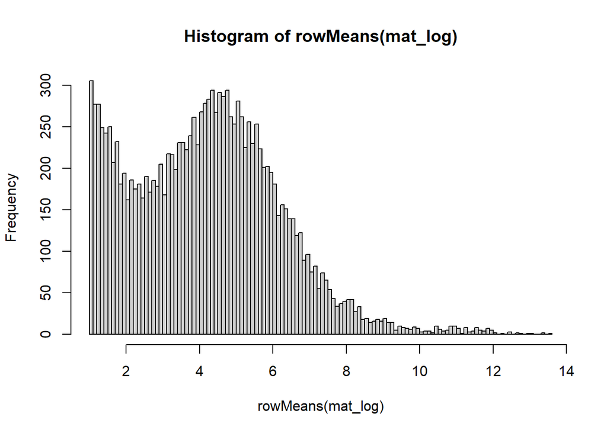

```r
hist(rowMeans(mat_log), breaks = 100)
```

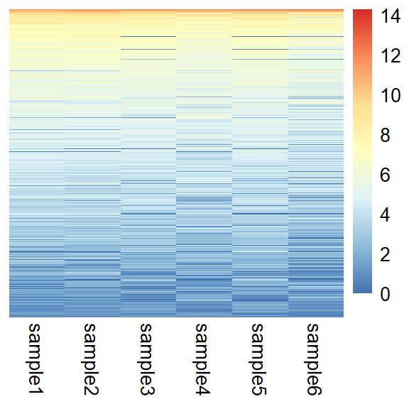

```r
pheatmap(mat = mat_log,
         cluster_rows = F,
         cluster_cols = F,
         show_rownames = F)
```

何となくsample1, sample2, sample4が近く、sample3, sample5, sample6と は違ったプロファイルであることが見えてきました。

## 2-3. SDを用いた遺伝子のフィルタリング

サンプル間の違いを示すには上記までの遺伝子数はまだまだ多いと考えられます。 サンプルによって遺伝子発現量が違うのであれば、その遺伝子の分散や標準偏差は高くなるはずです。一方、内因性コントロルのような遺伝子は高発現であってもサンプル間での差は小さいため、サンプルの違いを示すには必要無いと考えられます。

遺伝子ごとの標準偏差を計算します。rowSD機能は無いので1行ごとに`sd`を繰り返します。 行列の繰り返しには`apply`を使用します。

`MARGIN = 1`で行ごと、`MARGIN = 2`で列ごとに処理を繰り返します。繰り返す処理内容は`FUN=`で指定します。

```r
# 行ごとにsd()を実施
gene_sd <- apply(X = mat_log, MARGIN = 1, FUN = sd)
head(gene_sd)
```

```
##    EEF1A1   MT-ND4L   MT-ATP8    MT-ND3    MT-CO2     RPS27
## 0.3246867 0.6496367 0.3450002 0.3604278 0.6021013 0.3680607
```

```r
summary(gene_sd)
```

```
##    Min. 1st Qu.  Median    Mean 3rd Qu.    Max.
## 0.03429 0.41230 0.61704 0.75320 0.93545 5.01346
```

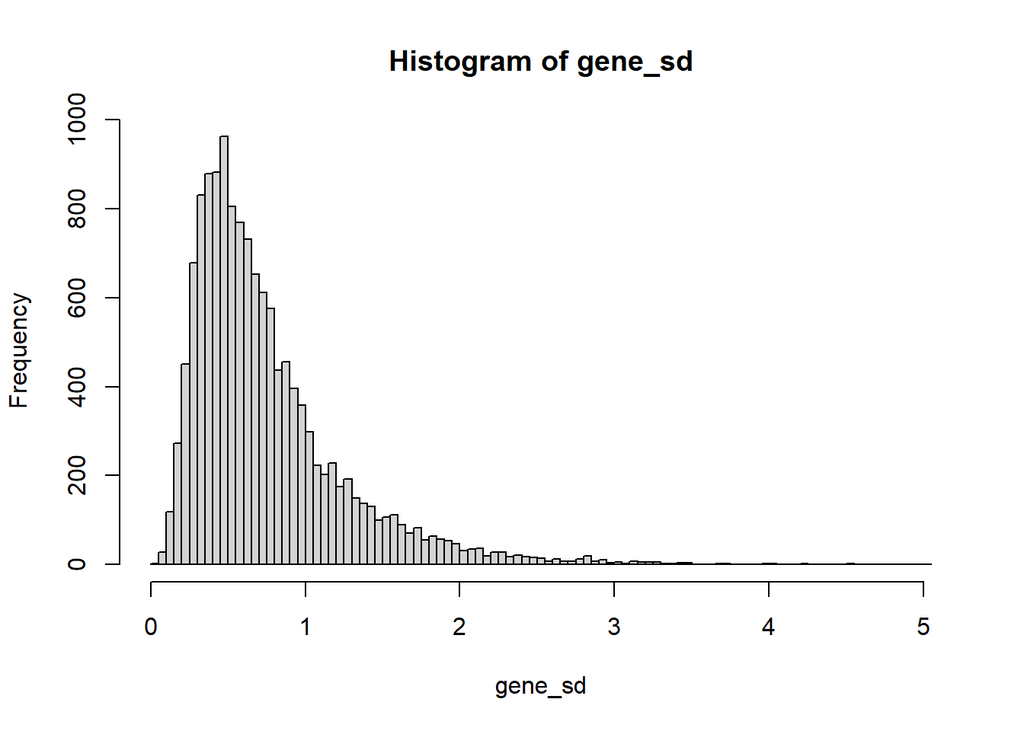

```r
hist(gene_sd, breaks = 100)
```

殆どの遺伝子が標準偏差1以内であり、サンプル間で発現が変動していないことが伺えます。

標準偏差が1以上の遺伝子のみを使用してみます。

```r
table(gene_sd >= 1)
```

```
##
## FALSE  TRUE
## 10896  2992
```

```r
mat_highSD <- mat_log[ gene_sd >= 1 , ]
dim(mat_highSD)
```

```
## [1] 2992    6
```

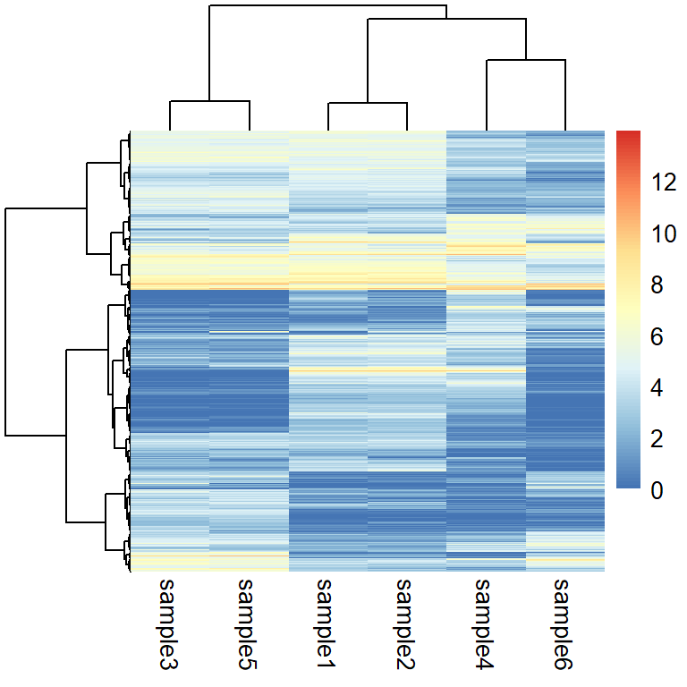

```r
pheatmap(mat = mat_highSD,
         show_rownames = F,
         clustering_method = "ward.D")
```

サンプル間の違いをはっきりと表現することができました。

行方向にscalingしても良いです。

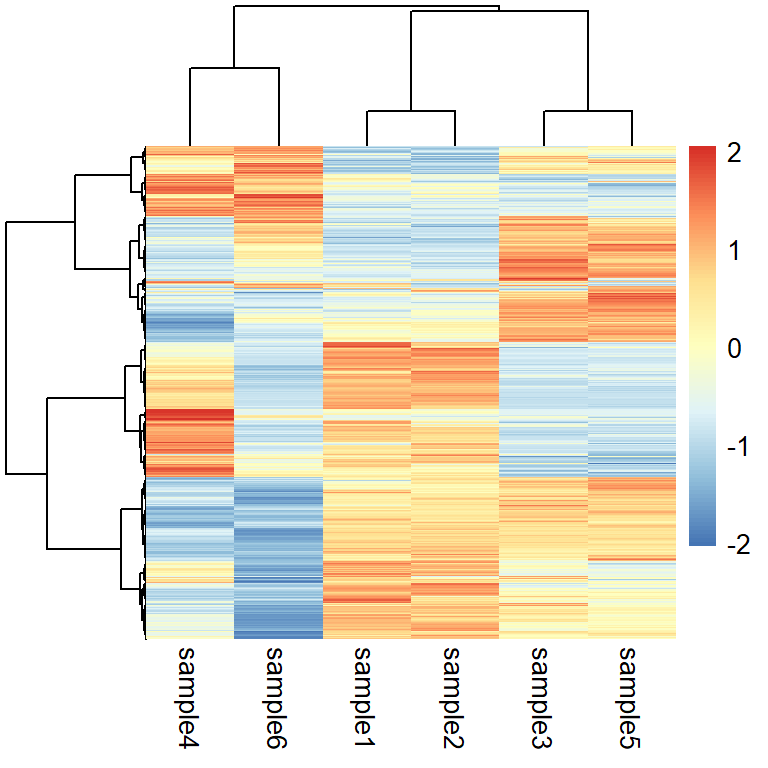

```r
pheatmap(mat = mat_highSD,
         scale = "row",
         show_rownames = F,
         clustering_method = "ward.D")
```

sample1と2, sample3と5が似たプロファイルを持ち、sample4, sample6は他と異なるプロファイルであることが分かりました。

## 2-4. 主成分分析

遺伝子数(1万4千) × サンプル という多次元でサンプル間の違いを可視化するのは困難です。

主成分分析では多次元の遺伝子情報のうち、サンプル間の違いを説明するうえで重要な成分を抽出します。重要な成分ほど上位の成分となります。基本は第一成分と第二成分を用いてサンプル間の違いを示します。

Rで主成分分析をするには`prcomp`機能を使用します。※ 列に配置した情報から成分を分析します。遺伝子の情報を成分分析したいので`t`機能で行列を転置して、サンプル × 遺伝子 の行列にしてから使用します。

```r
pca_result <- prcomp(x = t(mat_log))
str(pca_result)
```

```
## List of 5
##  $ sdev    : num [1:6] 72.5 67 28.1 22.4 20.1 ...
##  $ rotation: num [1:13888, 1:6] 0.00179 0.00777 0.00234 0.0044 0.00383 ...
##   ..- attr(*, "dimnames")=List of 2
##   .. ..$ : chr [1:13888] "EEF1A1" "MT-ND4L" "MT-ATP8" "MT-ND3" ...
##   .. ..$ : chr [1:6] "PC1" "PC2" "PC3" "PC4" ...
##  $ center  : Named num [1:13888] 13.5 13.3 13.4 13 12.9 ...
##   ..- attr(*, "names")= chr [1:13888] "EEF1A1" "MT-ND4L" "MT-ATP8" "MT-ND3" ...
##  $ scale   : logi FALSE
##  $ x       : num [1:6, 1:6] -75.6 -71.4 63.8 -50.1 64.7 ...
##   ..- attr(*, "dimnames")=List of 2
##   .. ..$ : chr [1:6] "sample1" "sample2" "sample3" "sample4" ...
##   .. ..$ : chr [1:6] "PC1" "PC2" "PC3" "PC4" ...
##  - attr(*, "class")= chr "prcomp"
```

出力のうち、xの箇所がサンプルごとの主成分です。

ggplotを用いて第一成分、第二成分上のサンプル分布を確認してみます。

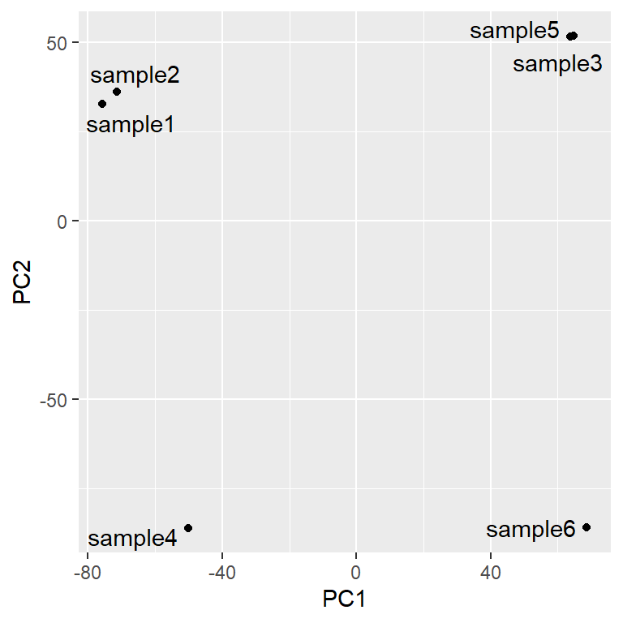

```r
library(ggplot2)
library(ggrepel) # install.packages("ggrepel")
ggplot(data = data.frame(pca_result$x),
       aes(x = PC1, y = PC2, label = rownames(pca_result$x))) +
  geom_point() +
  geom_text_repel() # ラベルの重なりを防いでラベル表示
```

上記のSDが高い遺伝子を用いて行った階層的クラスタリングと同様の解釈が得られました。

ちなみに第三成分、第四成分を可視化すると異なる結果が得られます。PCAのどの成分を使うかは自身で決めて構いません。

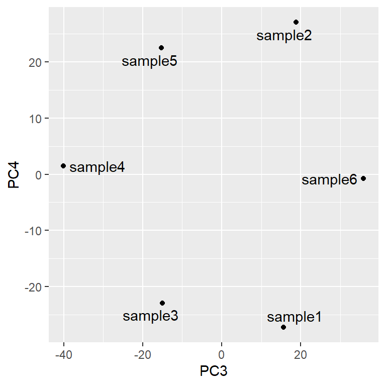

```r
ggplot(data = data.frame(pca_result$x),
       aes(x = PC3, y = PC4, label = rownames(pca_result$x))) +
  geom_point() +
  geom_text_repel() # ラベルの重なりを防いでラベル表示
```

## 2-5. tSNE, UMAP

最近、流行りのtSNEやUMAPもRで簡単に実行することができます。主成分分析と異なり、多次元を2次元に落とし込むためサンプル間の違いを示す際に成分軸を選ぶ必要がありません。

```r
library(Rtsne) # install.packages("ggrepel")

# tSNEは乱数を使うのでseed値を固定します
set.seed(0)

# tSNEの実行
tsne_result <- Rtsne(X = t(mat_log),
                     perplexity = 1 # サンプル数が少ない時は下げる
                     )
```

ggplotで結果を確認します。

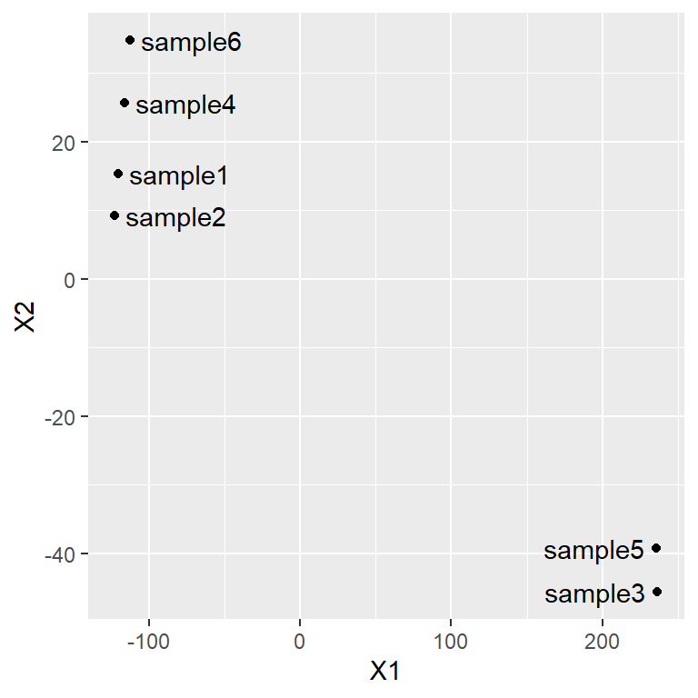

```r
df <- data.frame(tsne_result$Y, row.names = colnames(mat_log))
ggplot(data = df,
       aes(x = X1, y = X2, label = rownames(df))) +
  geom_point() +
  geom_text_repel() # ラベルの重なりを防いでラベル表示
```

```r
library(uwot) # install.packages("uwot")
# UMAPも乱数を使うのでseed値を固定します
set.seed(1)

# UMAPの実行
umap_result <- umap(t(mat_log),
                    n_neighbors = 6 # サンプル数以下を指定
                    )
```

ggplotで結果を確認します。

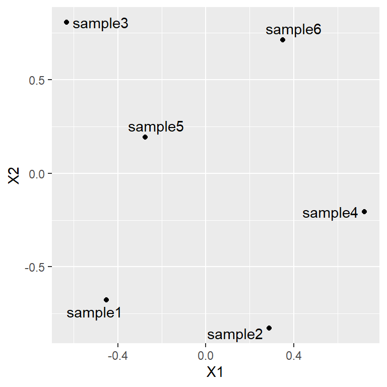

```r
df <- data.frame(umap_result)
ggplot(data = df,
       aes(x = X1, y = X2, label = rownames(df))) +
  geom_point() +
  geom_text_repel() # ラベルの重なりを防いでラベル表示
```

tSNEやUMAPは入れた情報を全て使いますので、想定のクラスタリング結果が得られていない要因として不要な情報を多く使っていることが考えられます。

どの次元削減方法も一長一短で、どれがベストとかはありません。